# PowerQuery - a practical introduction

Brendan Clarke, NHS Education for Scotland, brendan.clarke2@nhs.scot

17/07/2024

## Welcome

- 🌶 this session is a beginner-level introduction to PowerQuery
- we’ll get going properly at 14.35
- you’ll either Excel desktop (>2007) or Power BI desktop
- you’ll also need to have basic competency in Excel or Power BI
- if you can’t access the chat, you might need to join our Teams channel: [tinyurl.com/kindnetwork](https://teams.microsoft.com/l/team/19%3AQZ7-PbFVcziG2piHLt1_ifey3I2cwFL0yBuTSS8vVao1%40thread.tacv2/conversations?groupId=106d08f3-9026-40e2-b3c7-87cd87304d58&tenantId=10efe0bd-a030-4bca-809c-b5e6745e499a)
- you can find session materials at [tinyurl.com/kindtrp](https://nes-dew.github.io/KIND-training/)

## The KIND network

- a social learning space for staff working with **k**nowledge, **i**nformation, and **d**ata across health, social care, and housing in Scotland
- we offer social support, free training, mentoring, community events, …
- [Teams channel](https://teams.microsoft.com/l/team/19%3AQZ7-PbFVcziG2piHLt1_ifey3I2cwFL0yBuTSS8vVao1%40thread.tacv2/conversations?groupId=106d08f3-9026-40e2-b3c7-87cd87304d58&tenantId=10efe0bd-a030-4bca-809c-b5e6745e499a) / [mailing list](https://forms.office.com/pages/responsepage.aspx?id=veDvEDCgykuAnLXmdF5JmpopIZB9ynRJnrPUHVFccipURjM2NkZJUkhGOFlQRjQxRFhVUTgwT0UwVyQlQCN0PWcu)

## Excel / Power BI training sessions

| Session | Date | Area | Level |
| --- | --- | --- | --- |
| Lambda formulas in Excel | 13:00-13:30 Mon 15th July 2024 | Excel | 🌶🌶 : **intermediate-level** |
| Lookups in Excel | 13:00-14:30 Thu 1st August 2024 | Excel | 🌶🌶 : **intermediate-level** |
| Relative, absolute, mixed, structured, and R1C1 references in Excel | 15:00-16:00 Thu 8th August 2024 | Excel | 🌶🌶 : **intermediate-level** |

- this session is based on our [Power BI for Beginners](https://learn.nes.nhs.scot/70921) course
- but PowerQuery isn’t specific to Power BI - it’s brilliant for Excel too

## Session outline

- what is PowerQuery, and why might you use it?
- getting data into PowerQuery
- basic data wrangling
- joins (merges)
- pivots

## What is PowerQuery?

- Microsoft call it a [“data transformation and data preparation engine”](https://learn.microsoft.com/en-us/power-query/power-query-what-is-power-query)
- it’s been around since 2010, initially in Excel, and then in both Excel and Power BI
- uses code ([M Formula language](https://en.wikipedia.org/wiki/Power_Query)) but has GUI tools for most tasks

## How I think of PowerQuery

- the right way to load any real data into Excel

## Why might you use it?

- powerful
- easy, to start with at least…
- allows you to standardise data loading from different sources
- allows you to repeat data loading

## Getting data into PowerQuery (Excel)

1. Open Excel and create a new, blank, workbook
2. `Data` > `Get & Transform Data`

[figure not shown]

3. Pick `From Web` and supply the following URL - `https://raw.githubusercontent.com/rfordatascience/tidytuesday/master/data/2023/2023-07-25/scurvy.csv`
4. From the preview, select `Transform data` to open PowerQuery

## Getting data into PowerQuery (Power BI)

1. Open Power BI and start a new report
2. Select `Get data` > `From Web` button in the ribbon
3. Supply the following URL - `https://raw.githubusercontent.com/rfordatascience/tidytuesday/master/data/2023/2023-07-25/scurvy.csv`
4. From the preview, select `Transform data` to open PowerQuery

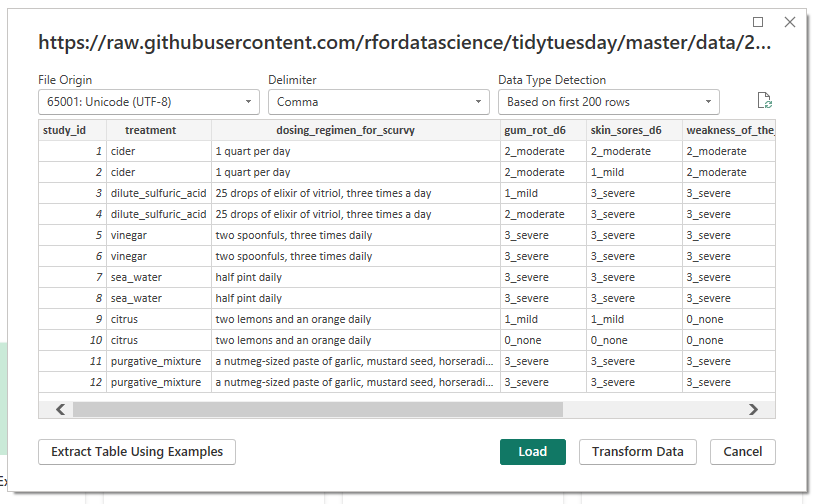

5. If you’ve already got some data in your report that you’d like to transform, use `Tranform data` in the ribbon to open PowerQuery:

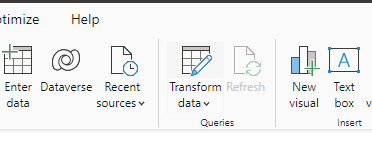

## Preview your Data

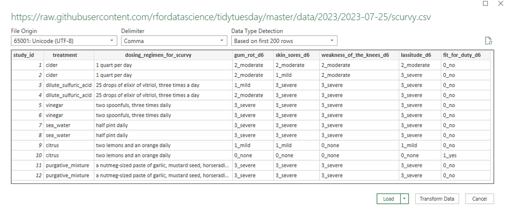

(make sure to click `Transform data`)

## First view of PowerQuery

[figure not shown]

First view of PowerQuery

- Queries (= datasets) on the left
- ribbon menu at the top
- Query settings (= the changes you’ll make to your data) on the right
- Excel-ish data preview in the middle

## Basic data wrangling

- right click the `study_id` column and select `Remove`
  - the column will disappear
  - but you’ll also gain a step in your Applied Steps field

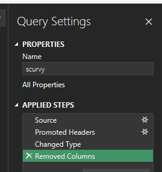

## Basic data wrangling

- you can edit this (and any) step
  - if you’re code-confident, you can edit the formula to read `= Table.RemoveColumns(#"Changed Type",{"study_id", "treatment"})` to also remove the treatment column
  - and you can remove the step using the X next to the step name
- you should also try renaming and reordering your columns in the same way
- once you’ve had a play, please remove the steps until you’re left with the data you started with (so delete back to “Changed Type”)

## Replacing values

- we can also work with individual values
- our values are a number, then an underscore, then a word
- we can `Split column` at the underscore
- we could also replace the odd underscores in the treatment column

## Reshaping data

- we could go column by column here splitting, but an easier approach would be to re-shape the data
- select the first three columns, and select `Unpivot Other Columns`

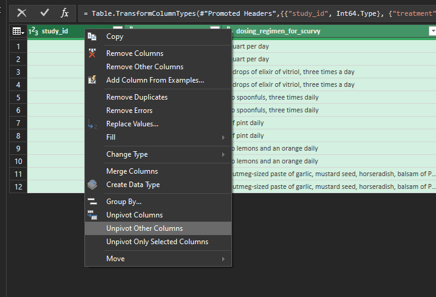

- then split, change type, and generally tidy up

## Add columns

Our treatment and dosing columns are annoying. Let’s make a new, joined, column for them:

- select `Custom Column`

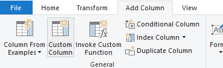

- you can click the gearwheel next to the step if you’d like to go back and tweak

## Close and load / Close and Apply sends your data back to Excel/Power BI

## Getting more fancy: a bigger dataset

- please load the Health and Care Experience survey results from 2023-4

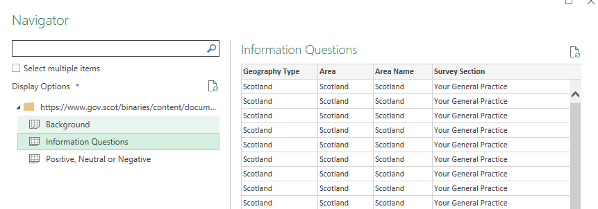

- or [alternative local version](https://github.com/NES-DEW/KIND-training/raw/main/excel/src/HACE_2023-4.xlsx)
- please load both the proper datasets (and ignore the background)

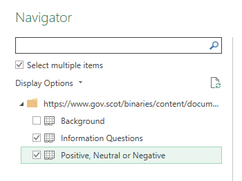

## A challenge

Can you find the number of responses to each question for your local NHS board? You should be able to re-work this data to give something like:

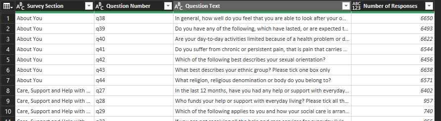

## Some hints

- filtering works like Excel, but is destructive
- unpivoting, doing something to all the rows, then re-pivoting is a great way to work across lots of columns
- you can join structurally similar datasets using `Append Queries as New`

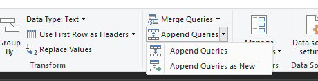

- you can deduplicate entire datasets by selecting all the columns and using `Remove Rows` > `Remove Duplicates`

## Feedback and resources

- please can I ask for some feedback - takes less than a minute, completely anonymous, helps people like you find the right training for them

| Session | Date | Area | Level |
| --- | --- | --- | --- |
| Lambda formulas in Excel | 13:00-13:30 Mon 15th July 2024 | Excel | 🌶🌶 : **intermediate-level** |
| Lookups in Excel | 13:00-14:30 Thu 1st August 2024 | Excel | 🌶🌶 : **intermediate-level** |
| Relative, absolute, mixed, structured, and R1C1 references in Excel | 15:00-16:00 Thu 8th August 2024 | Excel | 🌶🌶 : **intermediate-level** |